# Proyecto integrativo: visualización de datos de videojuegos

# Ejercicio 9. Género y región

Construye una visualización para comparar ventas por género en Norteamérica, Europa y Japón.

Prepara los datos:

```r
ventas_region_genero <- videojuegos_limpio %>%
  group_by(Genre) %>%
  summarise(
    Norteamerica = sum(NA_Sales, na.rm = TRUE),
    Europa = sum(EU_Sales, na.rm = TRUE),
    Japon = sum(JP_Sales, na.rm = TRUE),
    .groups = "drop"
  ) %>%
  pivot_longer(
    cols = c(Norteamerica, Europa, Japon),
    names_to = "region",
    values_to = "ventas"
  )

ventas_region_genero
```

```
# A tibble: 36 × 3
   Genre     region       ventas
   <chr>     <chr>         <dbl>
 1 Action    Norteamerica  862.
 2 Action    Europa        516.
 3 Action    Japon         159.
 4 Adventure Norteamerica  102.
 5 Adventure Europa         63.8
 6 Adventure Japon          52.0
 7 Fighting  Norteamerica  221.
 8 Fighting  Europa        100
 9 Fighting  Japon          87.2
10 Misc      Norteamerica  402.
# ℹ 26 more rows
```

En tu página, incluye una gráfica que compare ventas por género y región.

Requisitos de la gráfica:

- Debe comparar al menos tres regiones.
- Debe permitir ver si el patrón por género cambia entre regiones.
- Puede usar barras agrupadas o facetas.
- Debe evitar saturarse con demasiada información.

Debajo de la gráfica, escribe una interpretación corta.

**Ver gráfica**

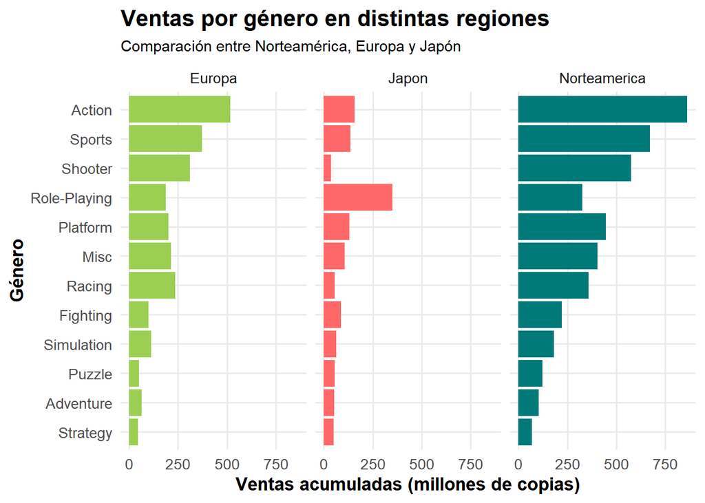

```r
ggplot(
  ventas_region_genero,
  aes(
    x = reorder(Genre, ventas),
    y = ventas,
    fill = region
  )
) +
  geom_col(show.legend = FALSE) +
  coord_flip() +
  facet_wrap(~region) +
  scale_fill_manual(
    values = c(
      "Norteamerica" = "#007979",
      "Europa" = "#9BCF53",
      "Japon" = "#FF6868"
    )
  ) +
  labs(
    title = "Ventas por género en distintas regiones",
    subtitle = "Comparación entre Norteamérica, Europa y Japón",
    x = "Género",
    y = "Ventas acumuladas (millones de copias)"
  ) +
  theme_videojuegos()
```

# Ejercicio 10. Pregunta propia

Propón una pregunta adicional que pueda responderse con esta base de datos y represéntala con una gráfica.

Tu análisis debe incluir:

- La pregunta que elegiste.
- La preparación de datos necesaria.
- Una gráfica hecha con `ggplot2`.
- Una interpretación breve.
- Una limitación de tu análisis.

Evita repetir exactamente los análisis anteriores. Puedes usar las mismas variables si las combinas de otra manera o si respondes una idea distinta.

Debajo de la gráfica, escribe una interpretación corta.

**Ver gráfica**

```r
# ¿Qué compañías (publishers) acumulan las mayores ventas globales?

top_publishers <- videojuegos_limpio %>%
  group_by(Publisher) %>%
  summarise(
    ventas_globales = sum(Global_Sales, na.rm = TRUE),
    numero_juegos = n(),
    .groups = "drop"
  ) %>%
  arrange(desc(ventas_globales)) %>%
  slice_head(n = 10)

top_publishers
```

```
# A tibble: 10 × 3
   Publisher                    ventas_globales numero_juegos
   <chr>                                  <dbl>         <int>
 1 Nintendo                               1784.           696
 2 Electronic Arts                        1093.          1339
 3 Activision                              721.           966
 4 Sony Computer Entertainment             607.           682
 5 Ubisoft                                 474.           918
 6 Take-Two Interactive                    399.           412
 7 THQ                                     340.           712
 8 Konami Digital Entertainment            279.           823
 9 Sega                                    271.           632
10 Namco Bandai Games                      254.           928
```

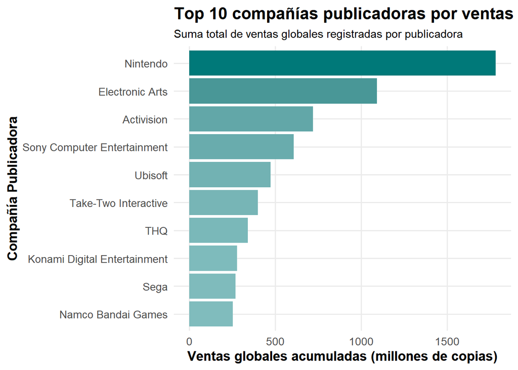

```r
top_publishers %>%
  mutate(Publisher = reorder(Publisher, ventas_globales)) %>%
  ggplot(aes(
    x = Publisher,
    y = ventas_globales,
    fill = ventas_globales
  )) +
  geom_col() +
  coord_flip() +
  scale_fill_gradient(
     low = "#80BCBD",
    high = "#007979"
  ) +
  labs(
    title = "Top 10 compañías publicadoras por ventas globales acumuladas",
    subtitle = "Suma total de ventas globales registradas por publicadora",
    x = "Compañía Publicadora",
    y = "Ventas globales acumuladas (millones de copias)"
  ) +
  theme_videojuegos() +
  theme(legend.position = "none")
```

# Guardar las gráficas

Para guardar una gráfica, primero guárdala como objeto.

Ejemplo:

```r
mi_grafica <- ggplot(top_plataformas, aes(x = fct_reorder(Platform, ventas_globales), y = ventas_globales)) +
  geom_col(width = 0.75) +
  coord_flip() +
  labs(
    title = "Top 10 plataformas por ventas globales",
    subtitle = "Ventas acumuladas en millones de copias",
    x = NULL,
    y = "Ventas globales",
    caption = "Fuente: Video Game Sales, Kaggle"
  ) +
  theme_videojuegos()

mi_grafica
```

Después usa `ggsave()`.

```r
ggsave(
  filename = "figures/grafica_final.png",
  plot = mi_grafica,
  width = 8,
  height = 5,
  dpi = 300
)
```

# Script de R

Además de tu página Quarto, crea un script llamado:

```
scripts/01_analisis_videojuegos.R
```

Ese script debe incluir:

1. Carga de paquetes.
2. Importación de datos.
3. Limpieza básica.
4. Código para preparar las tablas usadas en tus gráficas.
5. Código para generar tus gráficas.
6. Código para guardar al menos una figura con `ggsave()`.

# Renderizar la página

Cuando termines, renderiza tu archivo Quarto a HTML.

Desde RStudio puedes usar el botón `Render`.

Desde la terminal puedes usar:

```bash
quarto render ejercicio_videojuegos.qmd
```

Esto generará una página HTML con tus resultados.

# Cierre con Git

Revisa el estado del repositorio.

```bash
git status
```

Agrega los archivos modificados.

```bash
git add ejercicio_videojuegos.qmd
git add scripts/01_analisis_videojuegos.R
git add figures/
git add README.md
```

Haz un commit.

```bash
git commit -m "Agrega visualizaciones de datos de videojuegos"
```

# Entregable

El entregable es una página HTML generada con Quarto que contenga todos tus resultados.

Tu repositorio o carpeta de entrega debe incluir:

- Carpeta `data/` con la base de datos.
- Carpeta `scripts/` con tu script de R.
- Carpeta `figures/` con tus gráficas guardadas.
- Archivo `ejercicio_videojuegos.qmd`.
- Archivo HTML generado por Quarto.
- Archivo `README.md`.
- Al menos un commit claro.
- Interpretaciones breves debajo de las gráficas.

# Lista de verificación final

Antes de entregar, revisa lo siguiente:

- La página HTML se genera sin errores.
- Todas las gráficas aparecen correctamente.
- Cada gráfica responde una idea clara.
- Los títulos comunican el mensaje principal.
- Los ejes tienen nombres claros.
- Las unidades están indicadas cuando es necesario.
- Las categorías están ordenadas cuando corresponde.
- Las gráficas no están saturadas.
- Las interpretaciones no exageran lo que los datos permiten concluir.
- El repositorio tiene una estructura clara.